# 20074027 STAT2003 TASK 2

Bruce Odek Omondi

2025-05-12

# QUESTION B

## 1. Part 1: Analysis for 16-run design only with a 2-level factorial design

Opening the dataset

```r
# Load required packages
library(tidyverse)
# Read data
drugdata <- read.csv("antiviraldrugs.csv")
```

Start by subsetting the dataset to include only the first 16 runs for 2-level factorial design

```r
# Subset only the first 16 runs
drugdata_16 <- drugdata[1:16, ]
```

Then define the model that will be used to get the effect estimates

```r
# get the average readout and encode replicates as -1 and 1
drugs16 <- drugdata_16 %>%
  mutate(avg_readout = (Replicate1 + Replicate2) / 2,
         replicate = rep(c(-1, 1), each = 8))

# model on the first 16 runs
model16 <- lm(avg_readout ~ A + B + C + D + E +
                  A:B + A:C + A:D + A:E +
                  B:C + B:D + B:E +
                  C:D + C:E + D:E +
                  replicate,
                data = drugs16)

summary(model16)
```

```
##
## Call:
## lm(formula = avg_readout ~ A + B + C + D + E + A:B + A:C + A:D +
##     A:E + B:C + B:D + B:E + C:D + C:E + D:E + replicate, data = drugs16)
##
## Residuals:
## ALL 16 residuals are 0: no residual degrees of freedom!
##
## Coefficients: (1 not defined because of singularities)
##             Estimate Std. Error t value Pr(>|t|)
## (Intercept)  27.8469        NaN     NaN      NaN
## A            -2.9906        NaN     NaN      NaN
## B            -2.5469        NaN     NaN      NaN
## C             0.5375        NaN     NaN      NaN
## D           -19.6250        NaN     NaN      NaN
## E           -10.9687        NaN     NaN      NaN
## replicate    -2.7062        NaN     NaN      NaN
## A:B               NA         NA      NA       NA
## A:C           0.8094        NaN     NaN      NaN
## A:D           1.9969        NaN     NaN      NaN
## A:E          -1.3219        NaN     NaN      NaN
## B:C           2.4781        NaN     NaN      NaN
## B:D           0.2781        NaN     NaN      NaN
## B:E           1.1719        NaN     NaN      NaN
## C:D          -0.8906        NaN     NaN      NaN
## C:E           0.1656        NaN     NaN      NaN
## D:E           9.0156        NaN     NaN      NaN
##
## Residual standard error: NaN on 0 degrees of freedom
## Multiple R-squared:      1,  Adjusted R-squared:    NaN
## F-statistic:   NaN on 15 and 0 DF,  p-value: NA
```

The model turns out to be saturated (no degrees of freedom, p-val, etc.) so we cannot get the significance of the estimates. According to the textbook, this situation calls for the use of fold-over for the factorial design.

Fixing the 16-run design using fold-over to allow us to get the significance of the effect estimates

```r
# load libraries
library(tidyverse)

# getting only the first 16 runs
original16 <- drugdata[1:16, ] %>%
  mutate(
    avg_readout = (Replicate1 + Replicate2) / 2,  # average of Rep 1 and 2
    replicate = rep(c(-1, 1), each = 8)           # encode replicates as -1 and 1
  )
```

Fold-over requires us to flip the signs of all the levels for each factor

```r
# create folded-over design by reversing the signs of all factor levels
foldover16 <- original16 %>%
  mutate(
    A = -A, B = -B, C = -C, D = -D, E = -E,        # reverse signs as required for fold-over
    Run = Run + 100                                # label the foldover to differentiate from first 16
  )
```

Since we don’t have actual data for the fold-over runs, I opted to simulate readout values for the fold-over runs. Ideally, these would be actual data from doing the fold-over during the experiment

```r
# simulate placeholder readout values for fold-over runs
set.seed(123)  # for reproducibility

foldover16$avg_readout <- rnorm(16, mean = mean(original16$avg_readout), sd = sd(original16$avg_readout))
foldover16$replicate <- rep(c(-1, 1), each = 8)

# combine original and fold-over data into one dataset which will have 32 runs total
folded_data <- bind_rows(original16, foldover16)

# fit full second-order interaction model using the combined data
model_folded <- lm(avg_readout ~ A + B + C + D + E +
                                 A:B + A:C + A:D + A:E +
                                 B:C + B:D + B:E +
                                 C:D + C:E + D:E +
                                 replicate,
                   data = folded_data)
```

Then I defined a function that would be used to plot the half-normal plots of effects

```r
# define and generate a half-normal plot to assess effect significance
custom_half_normal <- function(model, model_name) {
  effects <- coef(model)[-1]  # exclude intercept
  abs_effects <- sort(abs(effects), decreasing = FALSE)
  n <- length(abs_effects)
  quantiles <- qnorm((1:n - 0.5) / n)

  plot(quantiles, abs_effects,
       main = paste("Half-Normal Plot –", model_name),
       xlab = "Normal Quantiles", ylab = "Absolute Effect", pch = 19)
  text(quantiles, abs_effects, labels = names(abs_effects), pos = 3, cex = 0.7)
  abline(lm(abs_effects ~ quantiles), col = "blue", lty = 2)
}

# output the summary and the plots
summary(model_folded)                    # Check model estimates
```

```
##
## Call:
## lm(formula = avg_readout ~ A + B + C + D + E + A:B + A:C + A:D +
##     A:E + B:C + B:D + B:E + C:D + C:E + D:E + replicate, data = folded_data)
##
## Residuals:
##     Min      1Q  Median      3Q     Max
## -32.903 -10.049   0.492   9.610  30.991
##
## Coefficients:
##             Estimate Std. Error t value Pr(>|t|)
## (Intercept)  31.3393     3.3339   9.400 1.12e-07 ***
## A            -1.8256     3.3339  -0.548  0.59203
## B            -3.5074     3.3339  -1.052  0.30943
## C            -3.5060     3.3339  -1.052  0.30962
## D           -12.2452     3.3339  -3.673  0.00226 **
## E            -5.0442     3.3339  -1.513  0.15106
## replicate    -8.8802     3.8497  -2.307  0.03576 *
## A:B          -0.5664     3.8497  -0.147  0.88498
## A:C           1.6112     3.3339   0.483  0.63587
## A:D           4.9725     3.3339   1.492  0.15656
## A:E           1.0932     3.3339   0.328  0.74752
## B:C           6.0404     3.3339   1.812  0.09008 .
## B:D           2.9756     3.3339   0.893  0.38620
## B:E          -0.4793     3.3339  -0.144  0.88759
## C:D          -5.6911     3.3339  -1.707  0.10842
## C:E          -2.3173     3.3339  -0.695  0.49763
## D:E          10.1721     3.3339   3.051  0.00809 **
## ---
## Signif. codes:  0 '***' 0.001 '**' 0.01 '*' 0.05 '.' 0.1 ' ' 1
##
## Residual standard error: 18.86 on 15 degrees of freedom
## Multiple R-squared:  0.7472, Adjusted R-squared:  0.4775
## F-statistic: 2.771 on 16 and 15 DF,  p-value: 0.02755
```

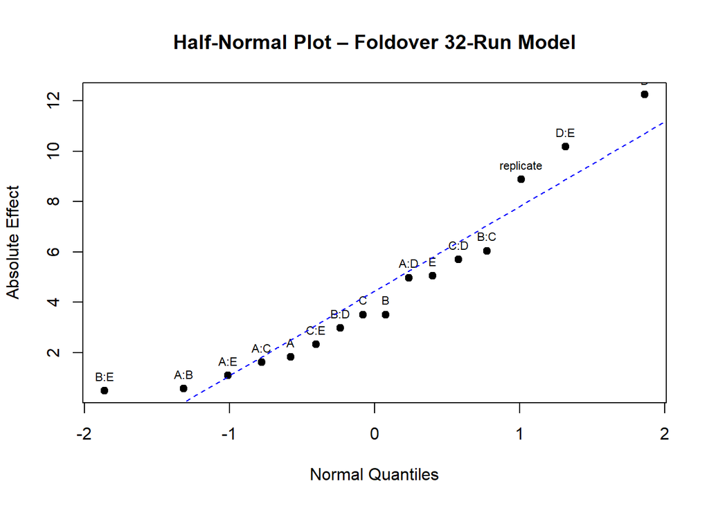

```r
custom_half_normal(model_folded, "Foldover 32-Run Model")  # Plot effect significance
```

Running some model diagnostic checks

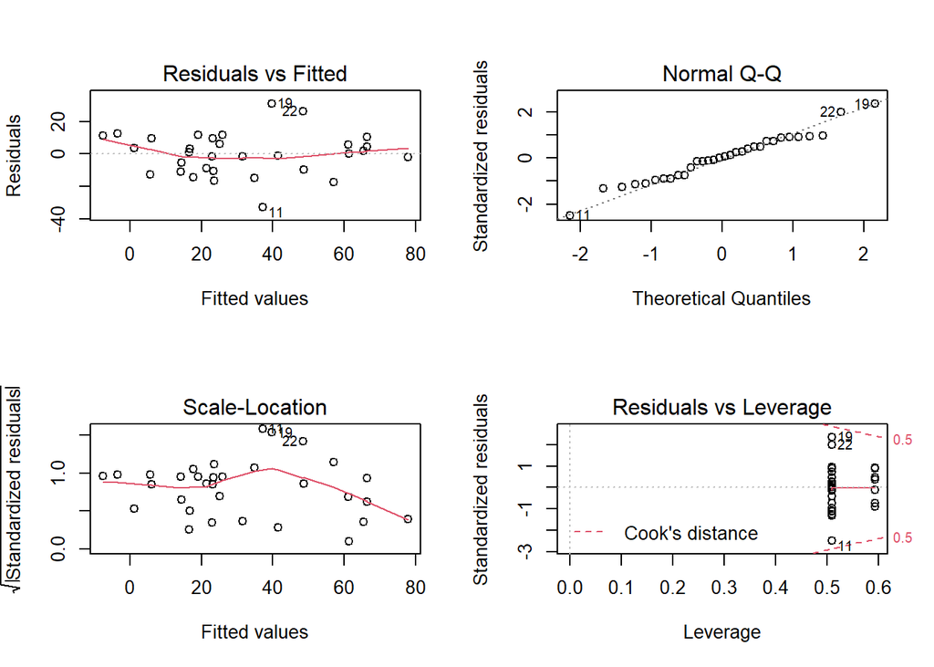

```r
# Plot standard diagnostic plots starting with the basic 4 plots
par(mfrow = c(2, 2))
plot(model_folded)
```

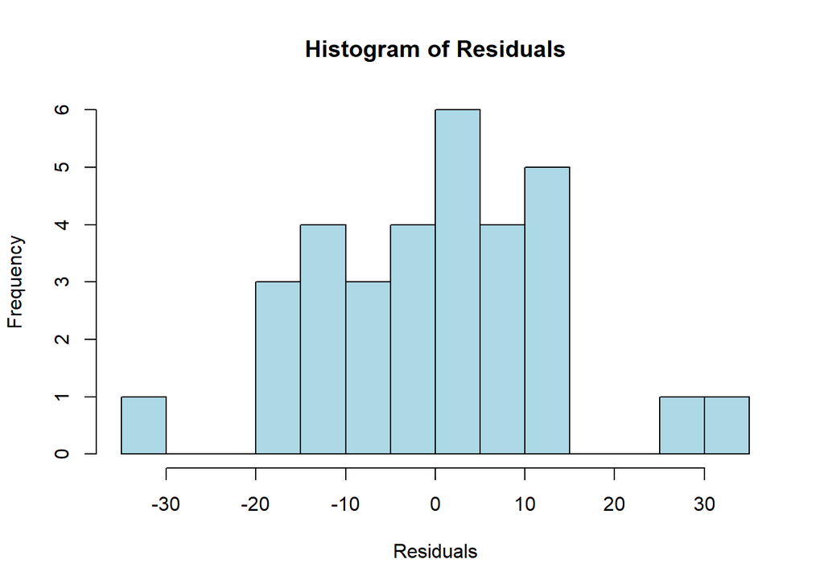

```r
# and some additional checks for normality
# Histogram of residuals
par(mfrow = c(1, 1))  # Reset layout
hist(residuals(model_folded), main = "Histogram of Residuals",
     xlab = "Residuals", col = "lightblue", breaks = 10)
```

```r
# Shapiro-Wilk test
shapiro.test(residuals(model_folded))
```

```
##
##  Shapiro-Wilk normality test
##
## data:  residuals(model_folded)
## W = 0.97519, p-value = 0.6529
```

## 2. Part 2(Bonus marks): Analysis to replicate estimates a,b, and c in Table III using all 34 runs (16-run and 18-run designs combined as they did in the paper)

I. Estimates in Table III (a) with y=readout and all runs included

```r
# we use the average readout, so y= readout
drugs_a <- drugdata %>%
  mutate(avg_readout = (Replicate1 + Replicate2) / 2,
         replicate = rep(c(-1, 1), each = 17))

# Fit full second-order model using raw response
model_a <- lm(avg_readout ~ A + B + C + D + E +
                I(A^2) + I(B^2) + I(C^2) + I(D^2) + I(E^2) +
                A:B + A:C + A:D + A:E +
                B:C + B:D + B:E +
                C:D + C:E + D:E +
                replicate,
              data = drugs_a)

# Summary of model (estimates should match Table III(a))
summary(model_a)
```

```
##
## Call:
## lm(formula = avg_readout ~ A + B + C + D + E + I(A^2) + I(B^2) +
##     I(C^2) + I(D^2) + I(E^2) + A:B + A:C + A:D + A:E + B:C +
##     B:D + B:E + C:D + C:E + D:E + replicate, data = drugs_a)
##
## Residuals:
##     Min      1Q  Median      3Q     Max
## -7.1366 -2.6036 -0.8743  2.4686  8.4523
##
## Coefficients:
##              Estimate Std. Error t value Pr(>|t|)
## (Intercept)  17.87589    6.76783   2.641  0.02152 *
## A            -1.59155    1.29155  -1.232  0.24144
## B            -2.35092    1.29155  -1.820  0.09374 .
## C            -2.00099    1.29155  -1.549  0.14727
## D           -19.57614    1.29155 -15.157 3.45e-09 ***
## E           -13.93498    1.29155 -10.789 1.57e-07 ***
## I(A^2)        3.52854    3.38347   1.043  0.31756
## I(B^2)        0.04055    3.38347   0.012  0.99063
## I(C^2)       -1.82319    3.38347  -0.539  0.59984
## I(D^2)       -7.33321    3.38347  -2.167  0.05103 .
## I(E^2)       15.27194    3.38347   4.514  0.00071 ***
## replicate    -0.17232    1.83306  -0.094  0.92665
## A:B           0.71654    1.40509   0.510  0.61933
## A:C           2.33747    1.40509   1.664  0.12207
## A:D           1.46124    1.40502   1.040  0.31883
## A:E          -1.32398    1.40502  -0.942  0.36461
## B:C           1.63732    1.40502   1.165  0.26652
## B:D          -0.27370    1.40509  -0.195  0.84881
## B:E           1.30919    1.40502   0.932  0.36981
## C:D          -0.65668    1.40502  -0.467  0.64860
## C:E           0.11626    1.40509   0.083  0.93542
## D:E           9.56342    1.40509   6.806 1.89e-05 ***
## ---
## Signif. codes:  0 '***' 0.001 '**' 0.01 '*' 0.05 '.' 0.1 ' ' 1
##
## Residual standard error: 6.504 on 12 degrees of freedom
## Multiple R-squared:  0.9762, Adjusted R-squared:  0.9345
## F-statistic: 23.42 on 21 and 12 DF,  p-value: 9.551e-07
```

2. Estimates in Table III (b) with y= sqrt(readout) after transformation and all runs included

```r
# use the data but with y= sqrt(readout)
drugs_b <- drugdata %>%
  mutate(avg_readout = (Replicate1 + Replicate2) / 2,
         sqrt_readout = sqrt(avg_readout),
         replicate = rep(c(-1, 1), each = 17))

# fit model using sqrt(readout)
model_b <- lm(sqrt_readout ~ A + B + C + D + E +
                I(A^2) + I(B^2) + I(C^2) + I(D^2) + I(E^2) +
                A:B + A:C + A:D + A:E +
                B:C + B:D + B:E +
                C:D + C:E + D:E +
                replicate,
              data = drugs_b)

# Summary of model (estimates should match Table III(b))
summary(model_b)
```

```
##
## Call:
## lm(formula = sqrt_readout ~ A + B + C + D + E + I(A^2) + I(B^2) +
##     I(C^2) + I(D^2) + I(E^2) + A:B + A:C + A:D + A:E + B:C +
##     B:D + B:E + C:D + C:E + D:E + replicate, data = drugs_b)
##
## Residuals:
##      Min       1Q   Median       3Q      Max
## -0.70275 -0.18779 -0.04771  0.17332  0.77122
##
## Coefficients:
##              Estimate Std. Error t value Pr(>|t|)
## (Intercept)  4.045619   0.568363   7.118 1.22e-05 ***
## A           -0.133744   0.108464  -1.233 0.241159
## B           -0.230536   0.108464  -2.125 0.054998 .
## C           -0.200151   0.108464  -1.845 0.089798 .
## D           -2.059020   0.108464 -18.983 2.56e-10 ***
## E           -1.217984   0.108464 -11.229 1.01e-07 ***
## I(A^2)       0.244341   0.284144   0.860 0.406686
## I(B^2)       0.074547   0.284144   0.262 0.797497
## I(C^2)      -0.001232   0.284144  -0.004 0.996612
## I(D^2)      -1.172732   0.284144  -4.127 0.001402 **
## I(E^2)       1.393339   0.284144   4.904 0.000364 ***
## replicate   -0.012681   0.153941  -0.082 0.935707
## A:B          0.124954   0.118000   1.059 0.310481
## A:C          0.259862   0.118000   2.202 0.047945 *
## A:D          0.072360   0.117994   0.613 0.551156
## A:E         -0.130754   0.117994  -1.108 0.289515
## B:C          0.142028   0.117994   1.204 0.251915
## B:D         -0.093080   0.118000  -0.789 0.445524
## B:E          0.129679   0.117994   1.099 0.293313
## C:D         -0.105543   0.117994  -0.894 0.388652
## C:E          0.053797   0.118000   0.456 0.656596
## D:E          0.535907   0.118000   4.542 0.000676 ***
## ---
## Signif. codes:  0 '***' 0.001 '**' 0.01 '*' 0.05 '.' 0.1 ' ' 1
##
## Residual standard error: 0.5462 on 12 degrees of freedom
## Multiple R-squared:  0.9815, Adjusted R-squared:  0.9492
## F-statistic: 30.37 on 21 and 12 DF,  p-value: 2.17e-07
```

3. Estimates in Table III (c) with y= sqrt(readout) and Replicate 1 of run 14 removed

```r
# Clean the dataset - remove replicate 1 of run 14 and use sqrt(readout)
drugs_c <- drugdata %>%
  mutate(Replicate1 = ifelse(Run == 14, NA, Replicate1)) %>%
  mutate(avg_readout = rowMeans(select(., Replicate1, Replicate2), na.rm = TRUE),
         sqrt_readout = sqrt(avg_readout),
         replicate = rep(c(-1, 1), each = 17))

# fit the full second-order model
model_c <- lm(sqrt_readout ~ A + B + C + D + E +
                I(A^2) + I(B^2) + I(C^2) + I(D^2) + I(E^2) +
                A:B + A:C + A:D + A:E +
                B:C + B:D + B:E +
                C:D + C:E + D:E +
                replicate,
              data = drugs_c)

# View model summary (same estimates as Table III(c))
summary(model_c)
```

```
##
## Call:
## lm(formula = sqrt_readout ~ A + B + C + D + E + I(A^2) + I(B^2) +
##     I(C^2) + I(D^2) + I(E^2) + A:B + A:C + A:D + A:E + B:C +
##     B:D + B:E + C:D + C:E + D:E + replicate, data = drugs_c)
##
## Residuals:
##     Min      1Q  Median      3Q     Max
## -0.5020 -0.1979 -0.0292  0.1546  0.5969
##
## Coefficients:
##             Estimate Std. Error t value Pr(>|t|)
## (Intercept)  4.02584    0.47738   8.433 2.18e-06 ***
## A           -0.10962    0.09110  -1.203 0.252052
## B           -0.26608    0.09110  -2.921 0.012823 *
## C           -0.22067    0.09110  -2.422 0.032183 *
## D           -2.03490    0.09110 -22.337 3.83e-11 ***
## E           -1.23851    0.09110 -13.595 1.19e-08 ***
## I(A^2)       0.25507    0.23866   1.069 0.306197
## I(B^2)       0.06670    0.23866   0.279 0.784649
## I(C^2)      -0.01213    0.23866  -0.051 0.960285
## I(D^2)      -1.16200    0.23866  -4.869 0.000386 ***
## I(E^2)       1.38244    0.23866   5.793 8.57e-05 ***
## replicate    0.01778    0.12930   0.137 0.892924
## A:B          0.16523    0.09911   1.667 0.121348
## A:C          0.28653    0.09911   2.891 0.013552 *
## A:D          0.04496    0.09911   0.454 0.658203
## A:E         -0.09556    0.09911  -0.964 0.353968
## B:C          0.10195    0.09911   1.029 0.323922
## B:D         -0.05280    0.09911  -0.533 0.603937
## B:E          0.08960    0.09911   0.904 0.383750
## C:D         -0.07035    0.09911  -0.710 0.491375
## C:E          0.02021    0.09911   0.204 0.841847
## D:E          0.56257    0.09911   5.676 0.000103 ***
## ---
## Signif. codes:  0 '***' 0.001 '**' 0.01 '*' 0.05 '.' 0.1 ' ' 1
##
## Residual standard error: 0.4588 on 12 degrees of freedom
## Multiple R-squared:  0.9869, Adjusted R-squared:  0.9639
## F-statistic: 42.96 on 21 and 12 DF,  p-value: 2.923e-08
```

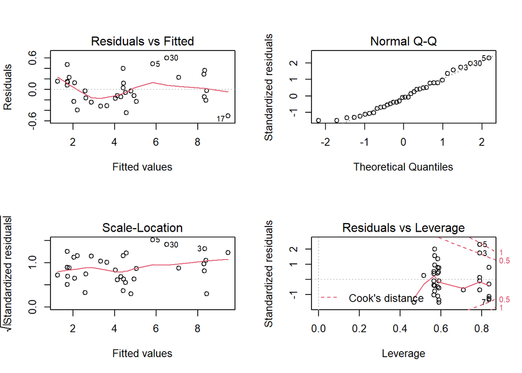

```r
# Diagnostic plots to check model assumptions
par(mfrow = c(2, 2))
plot(model_c)
```

Performing variable selection via stepwise regression to ensure there are no further significant effects before we re-plot the diagnostic plots to check for model assumptions.

```r
library(MASS)
# Stepwise regression to select significant effects
step_model <- stepAIC(model_c, direction = "both", trace = FALSE)

# final model output
summary(step_model)
```

```
##
## Call:
## lm(formula = sqrt_readout ~ A + B + C + D + E + I(A^2) + I(D^2) +
##     I(E^2) + A:B + A:C + A:E + B:C + D:E, data = drugs_c)
##
## Residuals:
##     Min      1Q  Median      3Q     Max
## -0.4590 -0.2182 -0.1234  0.2554  0.6367
##
## Coefficients:
##             Estimate Std. Error t value Pr(>|t|)
## (Intercept)  4.09019    0.22218  18.409 5.22e-14 ***
## A           -0.10242    0.07341  -1.395  0.17827
## B           -0.27317    0.07371  -3.706  0.00140 **
## C           -0.21201    0.07360  -2.880  0.00925 **
## D           -2.04714    0.07421 -27.585  < 2e-16 ***
## E           -1.21788    0.07382 -16.499 4.10e-13 ***
## I(A^2)       0.24187    0.17887   1.352  0.19140
## I(D^2)      -1.14291    0.17969  -6.361 3.31e-06 ***
## I(E^2)       1.35297    0.17909   7.555 2.79e-07 ***
## A:B          0.15727    0.08096   1.943  0.06628 .
## A:C          0.29607    0.08096   3.657  0.00157 **
## A:E         -0.10175    0.08060  -1.262  0.22133
## B:C          0.10690    0.08166   1.309  0.20537
## D:E          0.56397    0.08189   6.887 1.09e-06 ***
## ---
## Signif. codes:  0 '***' 0.001 '**' 0.01 '*' 0.05 '.' 0.1 ' ' 1
##
## Residual standard error: 0.3821 on 20 degrees of freedom
## Multiple R-squared:  0.9848, Adjusted R-squared:  0.975
## F-statistic: 99.81 on 13 and 20 DF,  p-value: 2.989e-15
```

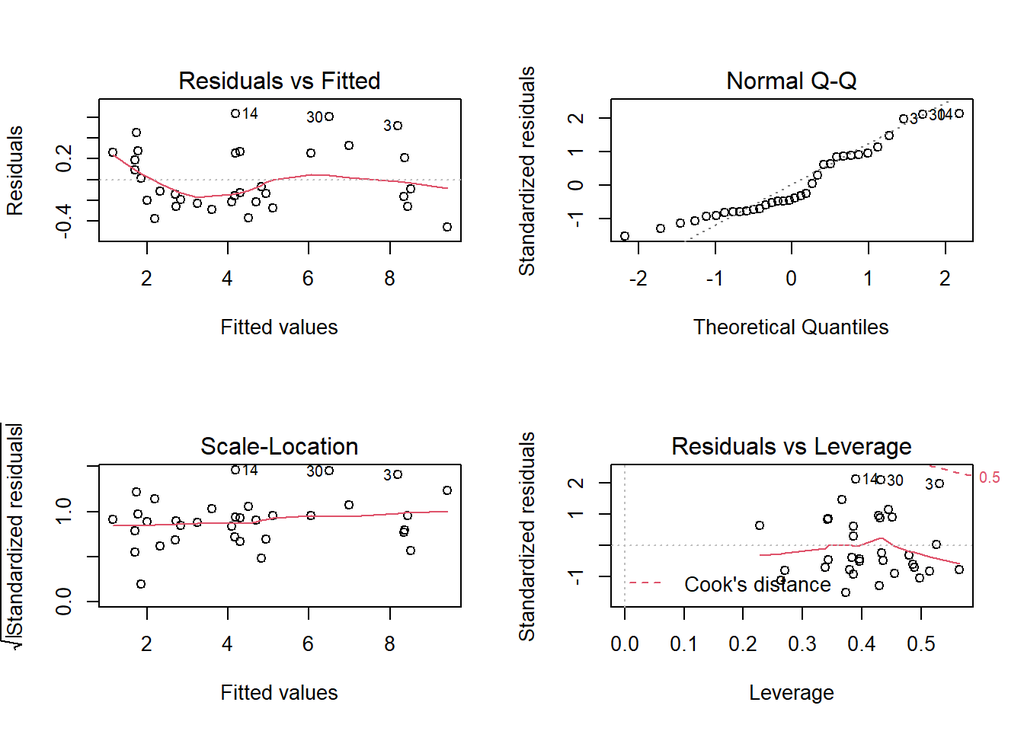

```r
# Diagnostic plots
par(mfrow = c(2, 2))
plot(step_model)
```

Models a, b, and c outputs are mostly similar to the output in Table 3 of the study, as explained in the MS Word file.